# Yale face data

- The database consists of 2410 images of 38 individuals.

```python
from sklearn.preprocessing import StandardScaler
from sklearn.model_selection import train_test_split
from sklearn.decomposition import PCA
import matplotlib.pyplot as plt
from scipy.io import loadmat
import pandas as pd
import numpy as np
import warnings
import time
warnings.filterwarnings("ignore")
import packages_and_functions as func
```

# Data Structure

- allFaces.mat provides keys and values of Yale faces.
- We need to create labels and get characteristics of faces by calling its keys ("faces" and "nfaces")

```python
faces_data = loadmat("allFaces.mat")
X = faces_data["faces"].T
y = []
for i, x in enumerate(faces_data["nfaces"][0]):
    y += [i+1] * x
group = np.unique(y)
```

## Part1. Original Data

### Data Preprocessing

- Split the data into training and testing part
- Standardization

Note: we assume that the test data is invisible, so we standardize test data with mean and std from train data.

```python
X_train, X_test, y_train, y_test = train_test_split(X, y, test_size=0.30, random_state = 410878048)

# Standardize the test data by means and std from train data
X_var_mean = np.array(np.mean(X_train, axis = 0)).reshape(1, -1)
X_var_std = np.array(np.std(X_train, axis = 0)).reshape(1, -1)
X_test = (X_test - X_var_mean)/ X_var_std

# Standardize the train data
scaler = StandardScaler()
X_train = scaler.fit_transform(X_train)
```

### Grid Search

Again, in order to get the maximized result, we in advance perform grid search.

Due to the need of a great deal of time handling larger data, we decide to reduce the sets of parameter we would try.

The final result shows, in training data, logistic regression model would get most excellent score under the set of parameter {'max_iter': 100, 'n_jobs': -1, 'penalty': 'l2', 'solver': 'lbfgs'}.

```python
# Logistics Regression parameters
params = {
    'penalty': ['l2'],
    'solver': ['lbfgs'],
    'max_iter': [100], "n_jobs" : [-1]
}
print("Logistic Regression")
log_params = func.gridSearch("LogisticReg", params, X_train, y_train)

# SVM parameters
params = {
    'C': [0.1],
    'kernel': ['linear'],
    'gamma': ['scale'],
    'degree': [2],
    'tol': [1e-5],
    'max_iter': [100]
}
print("SVM")
svm_params = func.gridSearch("SVM", params, X_train, y_train)

# Neural Network parameters
# Define a dictionary of hyperparameters to search over
params = {
    'hidden_layer_sizes': [(50,), (100,100)],
    'activation': ['relu'],
    'solver': [ 'adam'],
    'alpha': [ 0.01],
    'max_iter': [100],
    'tol': [1e-5]
}
print("Neural Network")
nn_params = func.gridSearch("NeuralNetwork", params, X_train, y_train)
```

```
Logistic Regression
Best hyperparameters: {'max_iter': 100, 'n_jobs': -1, 'penalty': 'l2', 'solver': 'lbfgs'}
Best score: 0.944290906536969
SVM
Best hyperparameters: {'C': 0.1, 'degree': 2, 'gamma': 'scale', 'kernel': 'linear', 'max_iter': 100, 'tol': 1e-05}
Best score: 0.9223605429037978
Neural Network
Best hyperparameters: {'activation': 'relu', 'alpha': 0.01, 'hidden_layer_sizes': (50,), 'max_iter': 100, 'solver': 'adam', 'tol': 1e-05}
Best score: 0.8867891068073674
```

### Classification Result

- Time of training of 3 models is about five minutes (320 sec)

```python
datas = [X_train, y_train, X_test, y_test]

# Start the timer
start_time = time.time()

CM_LogReg, _ = func.classificationChoice("LogisticReg", group, *datas, paras_dict = log_params)
CM_SVM, _ = func.classificationChoice("SVM", group, *datas, paras_dict = svm_params)
CM_NeuralNetwork, _ = func.classificationChoice("NeuralNetwork", group, *datas, paras_dict = nn_params)

# End the timer
end_time = time.time()

# Calculate the training time
training_time = end_time - start_time

print("Training time on original data: ", training_time)
```

```
Training time on original data:  320.6294775009155
```

- heatmaps of confusion matrix

  At this time, test data includes all of subjects, so we do not need to use stratify in train_test_split.

  Because of larger test data, more misclassified cases occurs, but most of them are correctly classified.

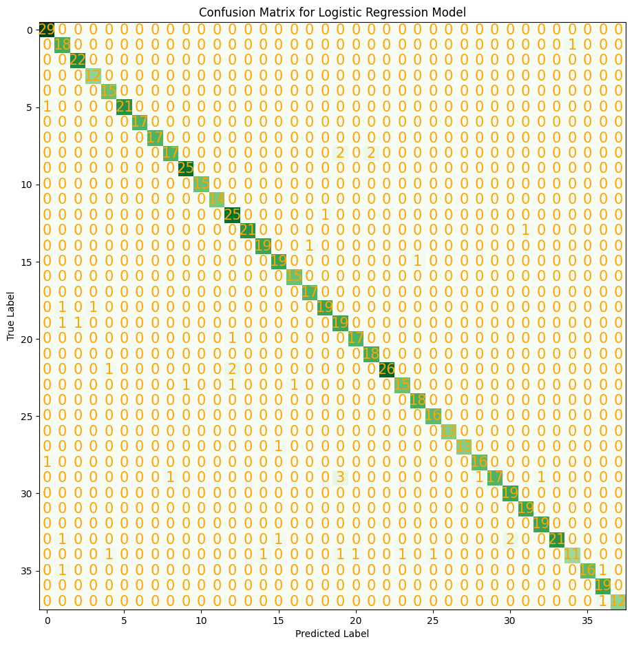

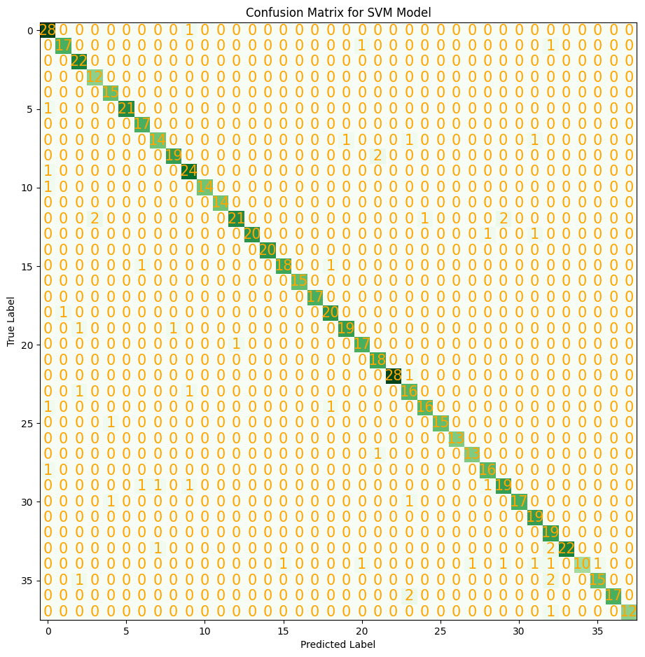

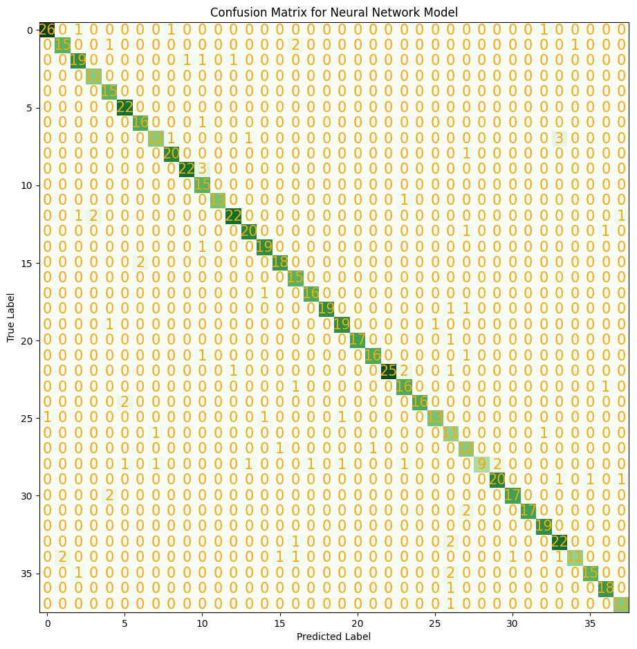

```python
model = ["Logistic Regression", "SVM", "Neural Network"]
for i, CM in enumerate([CM_LogReg, CM_SVM, CM_NeuralNetwork]):
    plt.figure(figsize=(11, 15))
    # Create a heatmap of the confusion matrix using seaborn
    plt.imshow(CM, cmap='Greens')

    # Add text to each cell of the heatmap
    for j in range(CM.shape[0]):
        for k in range(CM.shape[1]):
            text = plt.text(k, j, f'{CM[j, k]}', ha='center', va='center', color='Orange', fontsize=15)

    # Add labels for the x and y axes
    plt.xlabel('Predicted Label')
    plt.ylabel('True Label')
    plt.title(f'Confusion Matrix for {model[i]} Model')
    plt.show()
```

- Table of index

  When the index is below 60%, we color the cells in purple.

  These index become more stable than that of AT&T data because of larger test data.

```python
subject_id = ["Subject " + str(i) for i in range(1, len(np.unique(y)) + 1)]
result_table = func.modelResult([CM_LogReg, CM_SVM, CM_NeuralNetwork], subject_id)
result_table
```

|  | Precision(%) Logistic Regression | Precision(%) SVM | Precision(%) NeuralNetwork | Recall(%) Logistic Regression | Recall(%) SVM | Recall(%) NeuralNetwork |
| --- | --- | --- | --- | --- | --- | --- |
| Subject 1 | 93.5 | 84.8 | 96.3 | 100.0 | 96.6 | 89.7 |
| Subject 2 | 81.8 | 94.4 | 88.2 | 94.7 | 89.5 | 78.9 |
| Subject 3 | 95.7 | 88.0 | 86.4 | 100.0 | 100.0 | 86.4 |
| Subject 4 | 92.3 | 85.7 | 85.7 | 100.0 | 100.0 | 100.0 |
| Subject 5 | 88.2 | 88.2 | 78.9 | 100.0 | 100.0 | 100.0 |
| Subject 6 | 100.0 | 100.0 | 88.0 | 95.5 | 95.5 | 100.0 |
| Subject 7 | 100.0 | 89.5 | 88.9 | 100.0 | 100.0 | 94.1 |
| Subject 8 | 100.0 | 87.5 | 85.7 | 100.0 | 82.4 | 70.6 |
| Subject 9 | 94.4 | 95.0 | 90.9 | 81.0 | 90.5 | 95.2 |
| Subject 10 | 96.2 | 88.9 | 95.7 | 100.0 | 96.0 | 88.0 |
| Subject 11 | 100.0 | 100.0 | 68.2 | 100.0 | 93.3 | 100.0 |
| Subject 12 | 100.0 | 100.0 | 100.0 | 100.0 | 100.0 | 92.9 |
| Subject 13 | 86.2 | 95.5 | 91.7 | 96.2 | 80.8 | 84.6 |
| Subject 14 | 100.0 | 100.0 | 90.9 | 95.5 | 90.9 | 90.9 |
| Subject 15 | 95.0 | 100.0 | 90.5 | 95.0 | 100.0 | 95.0 |
| Subject 16 | 90.5 | 94.7 | 90.0 | 95.0 | 90.0 | 90.0 |
| Subject 17 | 93.8 | 100.0 | 75.0 | 100.0 | 100.0 | 100.0 |
| Subject 18 | 94.4 | 100.0 | 94.1 | 100.0 | 100.0 | 94.1 |
| Subject 19 | 95.0 | 90.9 | 100.0 | 90.5 | 95.2 | 90.5 |
| Subject 20 | 76.0 | 95.0 | 90.5 | 90.5 | 90.5 | 90.5 |
| Subject 21 | 94.4 | 89.5 | 100.0 | 94.4 | 94.4 | 94.4 |
| Subject 22 | 90.0 | 85.7 | 94.1 | 100.0 | 100.0 | 88.9 |
| Subject 23 | 100.0 | 100.0 | 100.0 | 89.7 | 96.6 | 86.2 |
| Subject 24 | 93.8 | 76.2 | 80.0 | 83.3 | 88.9 | 88.9 |
| Subject 25 | 94.7 | 94.1 | 100.0 | 100.0 | 88.9 | 88.9 |
| Subject 26 | 94.1 | 100.0 | 92.9 | 100.0 | 93.8 | 81.2 |
| Subject 27 | 100.0 | 100.0 | 55.0 | 100.0 | 100.0 | 84.6 |
| Subject 28 | 100.0 | 92.9 | 66.7 | 92.9 | 92.9 | 85.7 |
| Subject 29 | 94.1 | 88.9 | 100.0 | 94.1 | 94.1 | 52.9 |
| Subject 30 | 100.0 | 86.4 | 90.9 | 73.9 | 82.6 | 87.0 |
| Subject 31 | 90.5 | 100.0 | 94.4 | 100.0 | 89.5 | 89.5 |
| Subject 32 | 95.0 | 86.4 | 100.0 | 100.0 | 100.0 | 89.5 |
| Subject 33 | 95.0 | 73.1 | 90.5 | 100.0 | 100.0 | 100.0 |
| Subject 34 | 100.0 | 100.0 | 81.5 | 84.0 | 88.0 | 88.0 |
| Subject 35 | 91.7 | 100.0 | 91.7 | 64.7 | 58.8 | 64.7 |
| Subject 36 | 100.0 | 93.8 | 93.8 | 88.9 | 83.3 | 83.3 |
| Subject 37 | 90.5 | 100.0 | 90.0 | 100.0 | 89.5 | 94.7 |
| Subject 38 | 100.0 | 100.0 | 85.7 | 92.3 | 92.3 | 92.3 |
| Mean | 94.7 | 93.3 | 89.0 | 94.5 | 92.8 | 88.7 |

## Part2. PCA Data

### Data Preprocessing

- With dimensionality reduction, we retrieve more important variables from original data. Then, we check if the classification would be improved
- At the first experiment, retaining 80% variance leads to a terrible classification. Therefore, we turn to retain 70 variables which account for more than 95% variance of original data
- Train test split -> Standization -> PCA

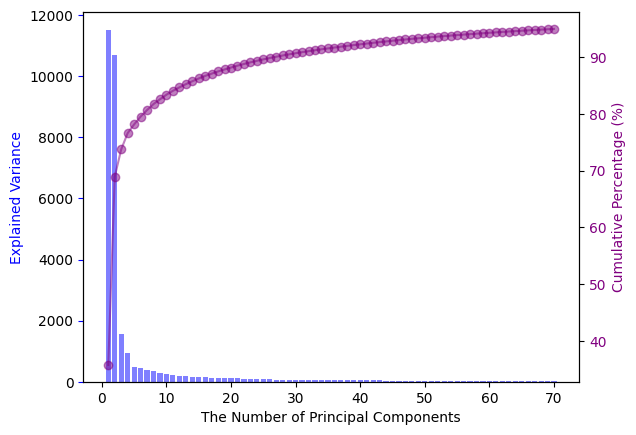

```python
X_train, X_test, y_train, y_test = train_test_split(X, y, test_size=0.30, random_state = 410878048)
# Standardize the test data by means and std from train data
X_var_mean = np.array(np.mean(X_train, axis = 0)).reshape(1, -1)
X_var_std = np.array(np.std(X_train, axis = 0)).reshape(1, -1)
X_test_std = (X_test - X_var_mean)/ X_var_std

# Standardize the train data
scaler = StandardScaler()
X_train_std = scaler.fit_transform(X_train)

pca = PCA()
pca.fit(X_train_std)
# decide the retained number of PCs
cumulative_variances = np.cumsum(pca.explained_variance_)
percentage = [x/X.shape[1] * 100 for x in cumulative_variances]
number_retained = list(np.array(percentage) > 95).count(False) + 1
explained_variance = pca.explained_variance_[:number_retained]
tick_of_pc = [x for x in range(1, len(explained_variance)+1)]

X_train = pca.transform(X_train_std)[:, :number_retained]
X_test = pca.transform(X_test_std)[:, :number_retained]

# show pca result
## plot bar chart
color1 = "blue"
plt.bar(tick_of_pc, explained_variance, color=color1, alpha=0.5)
plt.xlabel('The Number of Principal Components')
plt.ylabel('Explained Variance', color=color1)
plt.tick_params(axis='y', color=color1)
## create secondary y-axis
ax3 = plt.twinx()
## plot cumulative percentage line chart
ax3.plot(tick_of_pc, percentage[:number_retained], color='purple', marker='o', alpha = 0.5)
ax3.set_ylabel('Cumulative Percentage (%)', color='purple')
ax3.tick_params(axis='y', labelcolor='purple')
```

### Grid Search

The final result shows, in training data, Neural network model would get the most excellent score under the set of parameter {'activation': 'logistic', 'alpha': 0.0001, 'hidden_layer_sizes': (100,), 'max_iter': 1000, 'solver': 'adam', 'tol': 1e-05}.

```python
# Logistics Regression parameters
params = {
    'penalty': ['l1', 'l2', 'elasticnet'],
    'C': [0.1, 1, 10],
    'solver': ['newton-cg', 'lbfgs', 'sag'],
    'max_iter': [1000], "n_jobs" : [-1]
}
print("Logistic Regression")
log_params = func.gridSearch("LogisticReg", params, X_train, y_train)

# SVM parameters
params = {
    'C': [0.1, 1, 10],
    'kernel': ['linear', 'rbf'],
    'gamma': ['scale', 'auto'],
    'degree': [2, 5],
    'tol': [1e-5],
    'max_iter': [1000]
}
print("SVM")
svm_params = func.gridSearch("SVM", params, X_train, y_train)

# Neural Network parameters
# Define a dictionary of hyperparameters to search over
params = {
    'hidden_layer_sizes': [(50,), (100,), (100,100)],
    'activation': ['relu', 'tanh', 'logistic'],
    'solver': ['lbfgs', 'sgd', 'adam'],
    'alpha': [0.0001, 0.01],
    'max_iter': [1000],
    'tol': [1e-5]
}
print("Neural Network")
nn_params = func.gridSearch("NeuralNetwork", params, X_train, y_train)
```

```
Logistic Regression
Best hyperparameters: {'C': 0.1, 'max_iter': 1000, 'n_jobs': -1, 'penalty': 'l2', 'solver': 'lbfgs'}
Best score: 0.9359945920320264
SVM
Best hyperparameters: {'C': 0.1, 'degree': 2, 'gamma': 'scale', 'kernel': 'linear', 'max_iter': 1000, 'tol': 1e-05}
Best score: 0.9016118553895318
Neural Network
Best hyperparameters: {'activation': 'logistic', 'alpha': 0.0001, 'hidden_layer_sizes': (100,), 'max_iter': 1000, 'solver': 'adam', 'tol': 1e-05}
Best score: 0.9537724088283321
```

# Classification Result

- Time of training of 3 models is about only five seconds.

```python
datas = [X_train, y_train, X_test, y_test]

# Start the timer
start_time = time.time()

CM_LogReg, _ = func.classificationChoice("LogisticReg", group, *datas, paras_dict = log_params)
CM_SVM, _ = func.classificationChoice("SVM", group, *datas, paras_dict = svm_params)
CM_NeuralNetwork, _ = func.classificationChoice("NeuralNetwork", group, *datas, paras_dict = nn_params)

# End the timer
end_time = time.time()

# Calculate the training time
training_time = end_time - start_time

print("Training time on pca data: ", training_time)
```

```
Training time on pca data:  5.518352270126343
```

- heatmaps of confusion matrix In this cases, there is no obvious difference between 3 models from these confusion matrice.

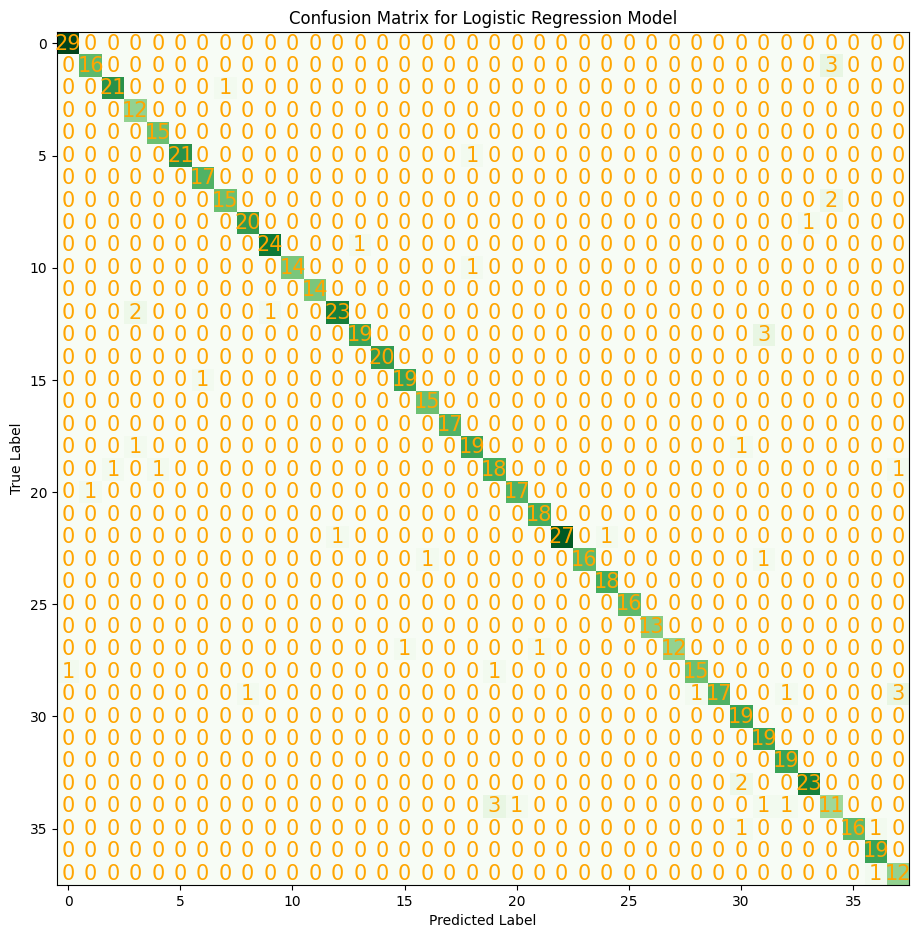

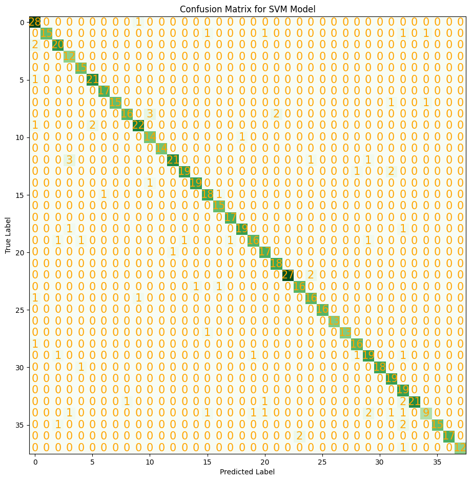

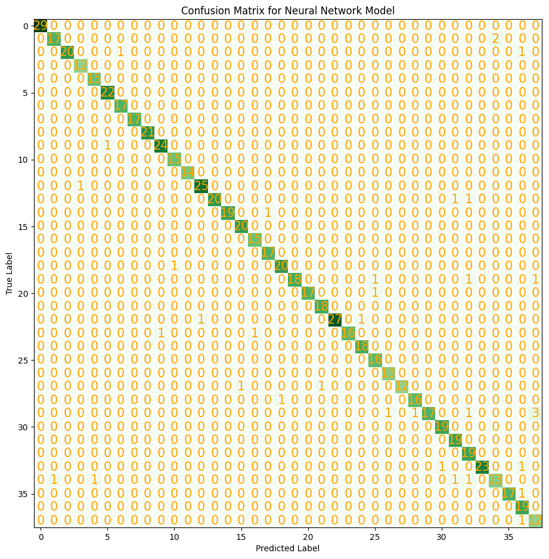

```python
model = ["Logistic Regression", "SVM", "Neural Network"]
for i, CM in enumerate([CM_LogReg, CM_SVM, CM_NeuralNetwork]):
    plt.figure(figsize=(11, 15))
    # Create a heatmap of the confusion matrix using seaborn
    plt.imshow(CM, cmap='Greens')

    # Add text to each cell of the heatmap
    for j in range(CM.shape[0]):
        for k in range(CM.shape[1]):
            text = plt.text(k, j, f'{CM[j, k]}', ha='center', va='center', color='Orange', fontsize=15)

    # Add labels for the x and y axes
    plt.xlabel('Predicted Label')
    plt.ylabel('True Label')
    plt.title(f'Confusion Matrix for {model[i]} Model')
    plt.show()
```

- Table of index

  Compared to original data, the number of purple cells has decreased in pca data, which means three models preform better than that.

  Among 3 models, Neural Network model achieve the best performance with high averaged precision (95.1%) and high averaged recall (95.4%).

```python
func.modelResult([CM_LogReg, CM_SVM, CM_NeuralNetwork], subject_id)
```

|  | Precision(%) Logistic Regression | Precision(%) SVM | Precision(%) NeuralNetwork | Recall(%) Logistic Regression | Recall(%) SVM | Recall(%) NeuralNetwork |
| --- | --- | --- | --- | --- | --- | --- |
| Subject 1 | 96.7 | 82.4 | 100.0 | 100.0 | 96.6 | 100.0 |
| Subject 2 | 94.1 | 100.0 | 94.4 | 84.2 | 78.9 | 89.5 |
| Subject 3 | 95.5 | 87.0 | 100.0 | 95.5 | 90.9 | 90.9 |
| Subject 4 | 80.0 | 70.6 | 92.3 | 100.0 | 100.0 | 100.0 |
| Subject 5 | 93.8 | 88.2 | 93.8 | 100.0 | 100.0 | 100.0 |
| Subject 6 | 100.0 | 91.3 | 95.7 | 95.5 | 95.5 | 100.0 |
| Subject 7 | 94.4 | 94.4 | 94.4 | 100.0 | 100.0 | 100.0 |
| Subject 8 | 93.8 | 100.0 | 100.0 | 88.2 | 88.2 | 100.0 |
| Subject 9 | 95.2 | 94.1 | 100.0 | 95.2 | 76.2 | 100.0 |
| Subject 10 | 96.0 | 91.7 | 96.0 | 96.0 | 88.0 | 96.0 |
| Subject 11 | 100.0 | 77.8 | 93.8 | 93.3 | 93.3 | 100.0 |
| Subject 12 | 100.0 | 100.0 | 100.0 | 100.0 | 100.0 | 100.0 |
| Subject 13 | 95.8 | 95.5 | 96.2 | 88.5 | 80.8 | 96.2 |
| Subject 14 | 95.0 | 95.0 | 100.0 | 86.4 | 86.4 | 90.9 |
| Subject 15 | 100.0 | 95.0 | 100.0 | 100.0 | 95.0 | 95.0 |
| Subject 16 | 95.0 | 85.7 | 95.2 | 95.0 | 90.0 | 100.0 |
| Subject 17 | 93.8 | 88.2 | 93.8 | 100.0 | 100.0 | 100.0 |
| Subject 18 | 100.0 | 94.4 | 94.4 | 100.0 | 100.0 | 100.0 |
| Subject 19 | 90.5 | 95.0 | 95.2 | 90.5 | 90.5 | 95.2 |
| Subject 20 | 81.8 | 88.9 | 100.0 | 85.7 | 76.2 | 85.7 |
| Subject 21 | 94.4 | 85.0 | 100.0 | 94.4 | 94.4 | 94.4 |
| Subject 22 | 94.7 | 90.0 | 94.7 | 100.0 | 100.0 | 100.0 |
| Subject 23 | 100.0 | 100.0 | 100.0 | 93.1 | 93.1 | 93.1 |
| Subject 24 | 100.0 | 88.9 | 100.0 | 88.9 | 88.9 | 88.9 |
| Subject 25 | 94.7 | 84.2 | 94.7 | 100.0 | 88.9 | 100.0 |
| Subject 26 | 100.0 | 100.0 | 88.9 | 100.0 | 100.0 | 100.0 |
| Subject 27 | 100.0 | 100.0 | 92.9 | 100.0 | 100.0 | 100.0 |
| Subject 28 | 100.0 | 100.0 | 100.0 | 85.7 | 92.9 | 85.7 |
| Subject 29 | 93.8 | 88.9 | 94.1 | 88.2 | 94.1 | 94.1 |
| Subject 30 | 100.0 | 82.6 | 100.0 | 73.9 | 82.6 | 73.9 |
| Subject 31 | 82.6 | 100.0 | 95.0 | 100.0 | 94.7 | 100.0 |
| Subject 32 | 79.2 | 82.6 | 90.5 | 100.0 | 100.0 | 100.0 |
| Subject 33 | 90.5 | 67.9 | 82.6 | 100.0 | 100.0 | 100.0 |
| Subject 34 | 95.8 | 100.0 | 100.0 | 92.0 | 84.0 | 92.0 |
| Subject 35 | 68.8 | 81.8 | 86.7 | 64.7 | 52.9 | 76.5 |
| Subject 36 | 100.0 | 100.0 | 100.0 | 88.9 | 83.3 | 94.4 |
| Subject 37 | 90.5 | 100.0 | 82.6 | 100.0 | 89.5 | 100.0 |
| Subject 38 | 75.0 | 100.0 | 75.0 | 92.3 | 92.3 | 92.3 |
| Mean | 93.5 | 91.2 | 95.1 | 93.6 | 91.0 | 95.4 |

## Conclusion

- With larger data, we need more time to train and test data.

  In original data, we spend 5 minutes testing, while, in pca data, we only spend 5 seconds testing.

  Surprisingly, the result in pca data performs even better.

  Although the original data can achieve this performance with the right selected parameter, the time we spend would be tremendous and not feasible for practical use.

  Therefore, it is recommended to adopt the dimensionality reduction method when we encouter big data rather than handle original data directly.